# Data Visualization

# **R Libraries**

- **`{dplyr}`** for arranging data frames
- The **G**rammar of **G**raphics: **`{ggplot}`**
- Libraries leveraging **`{ggplot2}`**; + others

# **The Grammar of Graphics Library: `{ggplot2}`**

## **5 components of `{ggplot2}`**

1. `Layer` containing geometric elements and data
2. `Scales` that map values in the data space to values in aesthetic space
3. `Coordinate System` for mapping coordinates to the graphic plane
4. `Facet` for arranging the data into a grid
5. `Theme` (e.g., like font, background, grids, axes, etc.)

# **Layers Contain**

1. `Data` (e.g., vector or data frame)
2. `Mapping` (e.g., aesthetics corresponding to data)
3. `Statistical Transformation` (e.g., sums, means, model fits, etc.)
4. `Geometric object` (geom) controlling the type of visualization
5. `Position Adjustment` (e.g., location of visual elements)

## **Data**

```r
DATA <- data.frame(
 var1 = c(1, 2, 3, 4),
 var2 = c(2, 5, 3, 8),
 var3 = c(10, 15, 32, 28),
 group = c("A", "A", "B", "B")
)
```

## **Data**

```r
DATA
```

```
  var1 var2 var3 group
1    1    2   10     A
2    2    5   15     A
3    3    3   32     B
4    4    8   28     B
```

## **Initialize the Plot Object**

```r
DATA |>
  ggplot()
```

# **Aesthetics**

- the visual elements of the data in the visualization
- color, fill, size, fill, shape, linetype, linewidth, transparency, etc.
- different geoms have/allow different aesthetics (e.g., lines have color but not fill)
- can be `constants` (e.g., blue) or mapped to data as `variables` (e.g., blue or red)

# **Mapping Data and Aesthetics**

## **Mapping**

- specified by arguments to `aes()`
- at least an `x` or `y` (e.g., `geom_histogram()`)
- some geoms need both (e.g., `geom_point()`, `geom_col()`, etc.)

## **Setting vs. Mapping**

- `mapping`: specified by arguments to `aes()`
- `setting`: specified by arguments in the `geom_*()`; outside of `aes()`

## **Mapping Data and Aesthetics (Cont.)**

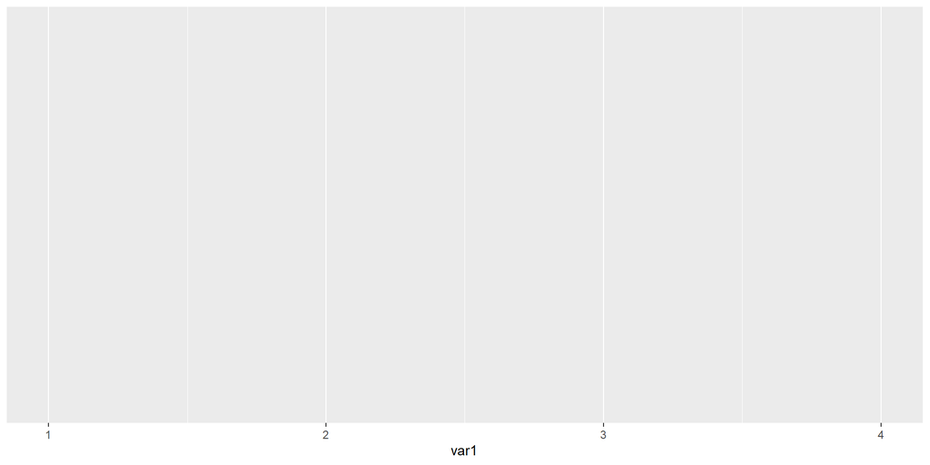

```r
DATA |>
  ggplot(mapping = aes(x = var1))
```

# **Plot Geometries**

- `x` or `y`: `geom_histogram()`, `geom_density()`, `geom_bar()`, etc.
- `x` & `y`:`geom_point()`, `geom_col()`, `geom_line()`, etc.

## **Adding Plot Geometries**

- add to object using `+` (don’t `|>`)

## **Adding a Geometry: `geom_histogram()`**

```r
geom_histogram(
  mapping = NULL,
  data = NULL,
  stat = "bin",
  position = "identity",
  ...
  )
```

## **Adding a Geometry: `geom_histogram()`**

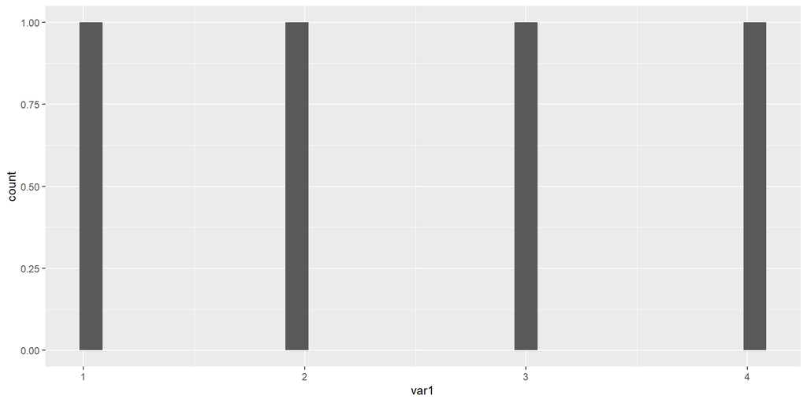

```r
DATA |>
  ggplot(mapping = aes(x = var1)) +
  geom_histogram()
```

## **Adding a Geometry: `geom_point()`**

```r
geom_point(
  mapping = NULL,
  data = NULL,
  stat = "identity",
  position = "identity",
  ...
  )
```

## **Adding a Geometry: `geom_point()`**

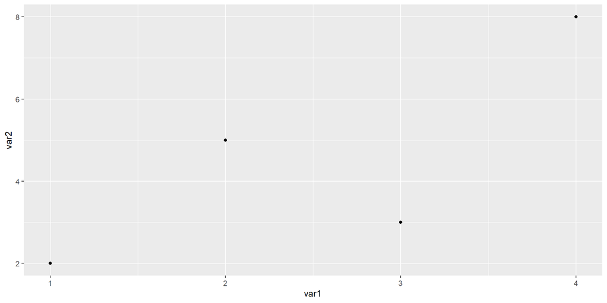

```r
DATA |>
  ggplot(mapping = aes(x = var1,
                       y = var2
                       )
         ) +
  geom_point()
```

## **Setting an Aesthetic: `Color`**

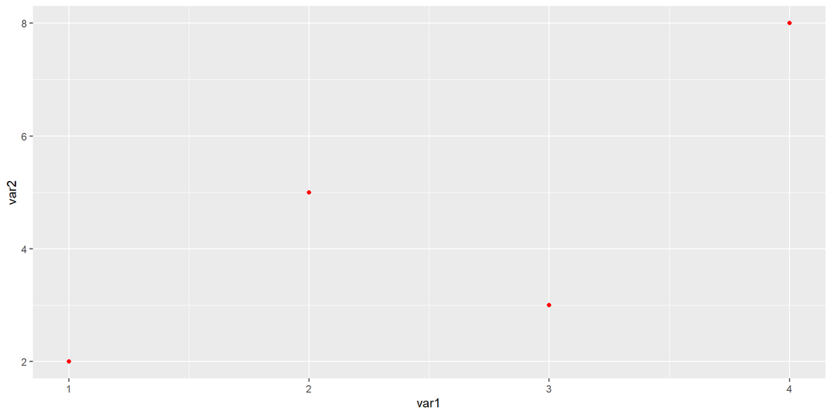

```r
DATA |>
  ggplot(mapping = aes(x = var1,
                       y = var2
                       )
         ) +
  geom_point(color = "red")
```

## **Mapping an Aesthetic: `Color`**

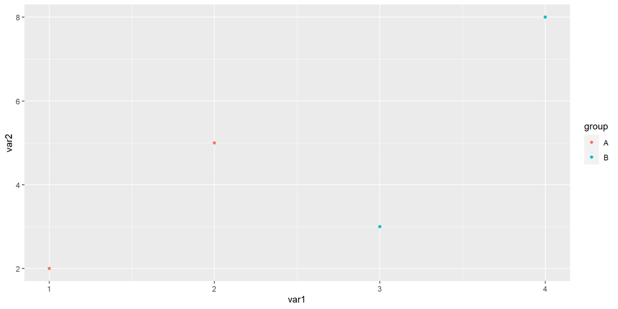

```r
DATA |>
  ggplot(mapping = aes(x = var1,
                       y = var2
                       )
         ) +
  geom_point(mapping = aes(color = group))
```

## **Errors with Mapping and Setting**

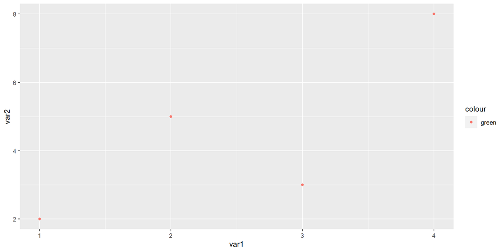

```r
DATA |>
  ggplot(mapping = aes(x = var1,
                       y = var2
                       )
         ) +
  geom_point(mapping = aes(color = "green"))
```

## **Adding a Geometry: `geom_col()`**

```r
geom_col(
  mapping = NULL,
  data = NULL,
  position = "stack",
  ...
  )
```

## **Adding a Geometry: `geom_col()`**

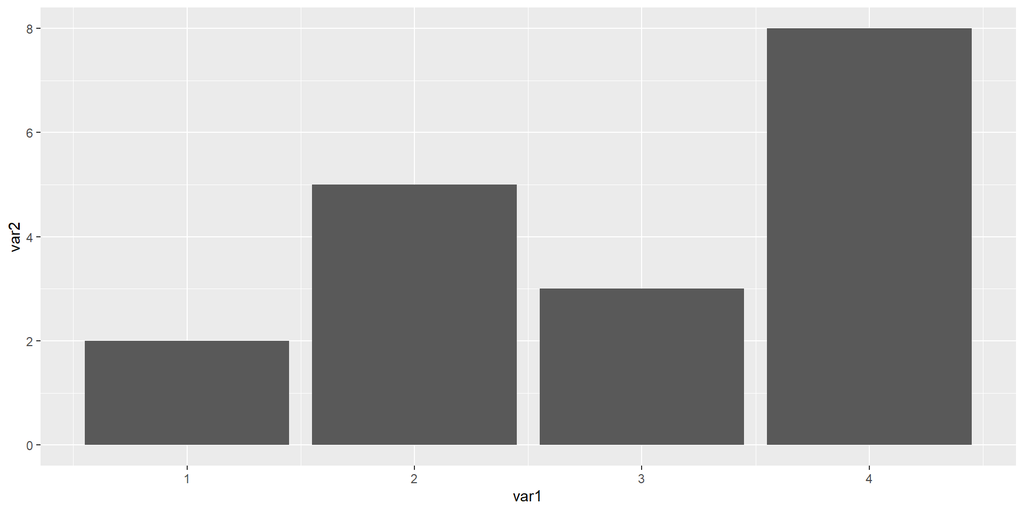

```r
DATA |>
  ggplot(mapping = aes(x = var1,
                       y = var2
                       )
         ) +
  geom_col()
```

## **Adding a Geometry: `geom_col()` (Cont.)**

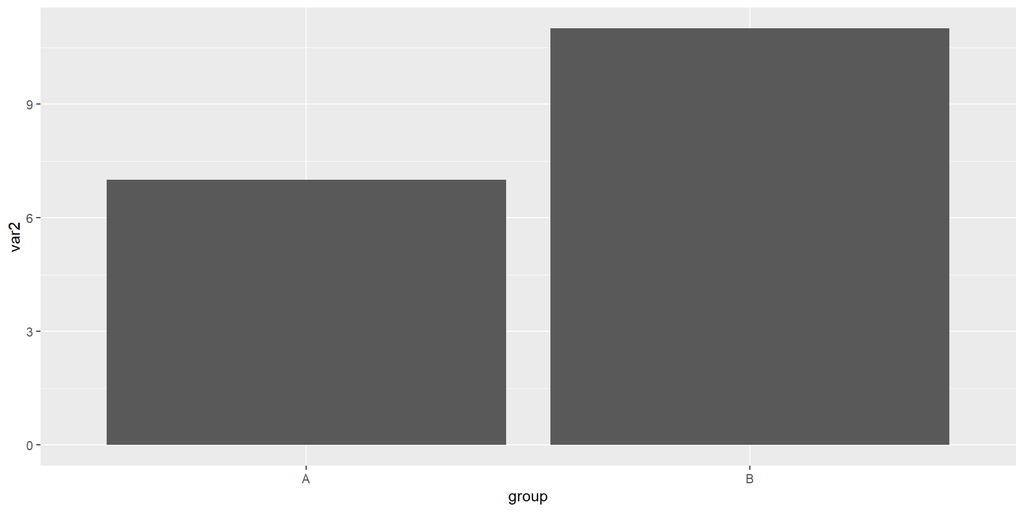

```r
DATA |>
  ggplot(mapping = aes(x = group,
                       y = var2
                       )
         ) +
  geom_col()
```

Notice anything odd?

## **Adding a Geometry: `geom_col()` (Cont.)**

Set aesthetics to make more apparent.

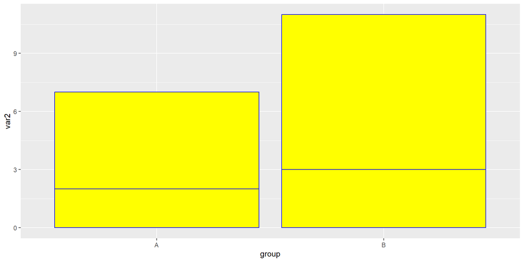

```r
DATA |>
  ggplot(mapping = aes(x = group,
                       y = var2
                       )
         ) +
  geom_col(fill = "yellow", color = "blue")
```

## **Remember the Data?**

```r
DATA
```

```
  var1 var2 var3 group
1    1    2   10     A
2    2    5   15     A
3    3    3   32     B
4    4    8   28     B
```

- all plots have some statistical transformation
- could be `"identity"` (what you see is what you get)
- could be based on a statistic (e.g., count, sum, mean, etc.)

## **Change the Data Frame (e.g., summarize)**

```r
DATA |>
  # aggregate across the groups, then summarize
  group_by(group) |>
  summarize(var2 = mean(var2, na.rm = TRUE))
```

```
# A tibble: 2 × 2
  group  var2
  <chr> <dbl>
1 A       3.5
2 B       5.5
```

## **Plot that New Data Frame**

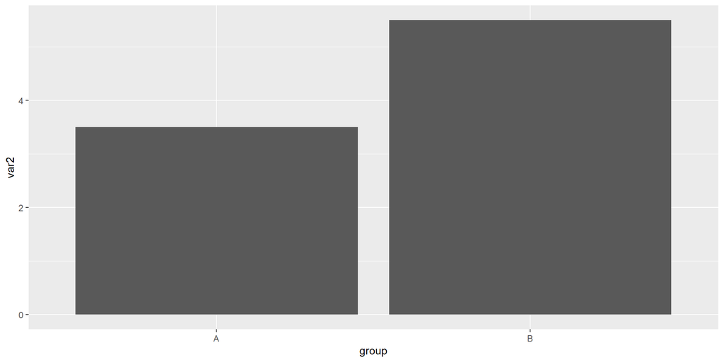

```r
DATA |>
  # aggregate across the groups, then summarize
  group_by(group) |>
  summarize(var2 = mean(var2, na.rm = TRUE)) |>

  # then plot
  ggplot(mapping = aes(x = group,
                       y = var2)
         ) +
  geom_col()
```

## **Adding a Geometry: `geom_boxplot()`**

```r
geom_boxplot(
  mapping = NULL,
  data = NULL,
  stat = "boxplot",
  position = "dodge2",
  ...
  )
```

## **Adding a Geometry: `geom_boxplot()`**

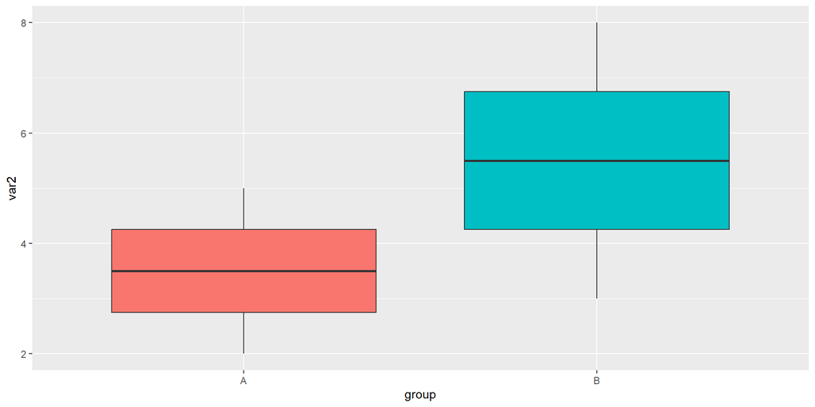

```r
DATA |>
  ggplot(mapping = aes(x = group,
                       y = var2
                       )
         ) +
  geom_boxplot(mapping = aes(fill = group),
               show.legend = FALSE
               )
```

# **Adding Multiple Geometries**

## **Adding Geometries as Plot Layers**

- *add* a layer using `+`
- specify the data
- map the aesthetics

## **Make Some New Data**

```r
DATA2 <-
  data.frame(
    var1 = rnorm(n = 100, mean = 20, sd = 2),
    var2 = rnorm(n = 100, mean = 55, sd = 3),
    group1 = rep(c("A", "B"), 50),
    group2 = rep(c("A", "A", "B", "B"), 25)
  )
```

## **Adding Geometry Layers: `geom_boxplot()` + `geom_point()`**

```r
DATA |>
  ggplot(mapping = aes(x = group,
                       y = var2
                       )
         ) +
  # add a boxplot layer; remove legend
  geom_boxplot(color = "black",
               fill = "white",
               show.legend = FALSE,
               notch = TRUE
               ) +
  # add a point layer with jittered points
  geom_point(position = position_jitter(width = .2),
             alpha = .7
             )
```

## **Adding Geometry Layers: `geom_boxplot()` + `geom_point()`**

[figure not shown]

# **Small Multiples**

## **Small Multiples: Replicating Plots for Subgroups**

- Sometimes you need create multiple plots by another variable
- Bar plots for each month; scatter plot for each city; etc.

## **Adding a Facet**

- a plot is in a facet by default
- to change the facet, *add* a facet layer
- `facet_wrap()` or `facet_grid()`

## **Adding a Facet Based on One Variable**

```r
DATA2 |>
  ggplot(mapping = aes(x = var1,
                       y = var2)
         ) +
  geom_point() +
  # facet by one variable
  facet_wrap(facets = vars(group1))
```

## **Adding a Facet Based on One Variable**

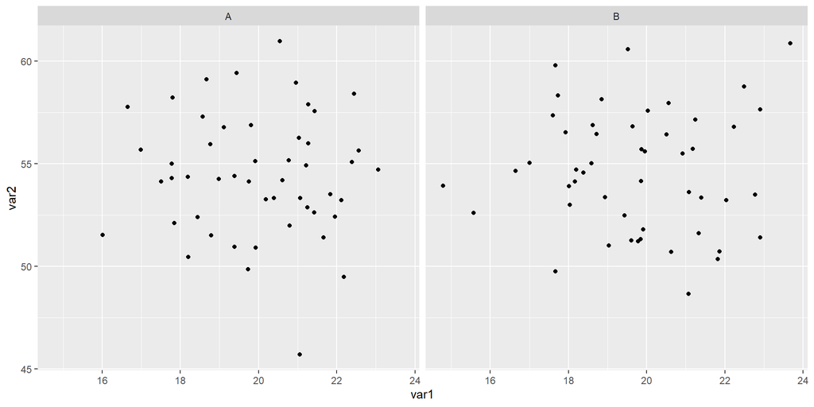

## **Adding a Facet Based on Two Variables**

[figure not shown]

## **Adding a Facet Based on Two Variables**

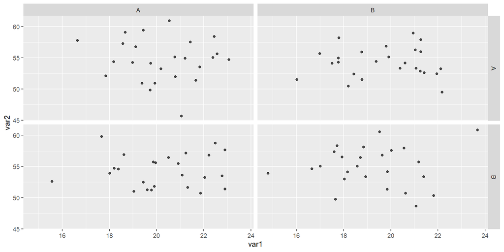

## **Adding a Theme**

- a plot is in a theme by default
- to change a theme, *add* a theme layer

## **Adding a Theme**

```r
DATA2 |>
  ggplot(mapping = aes(x = var1,
                       y = var2)
         ) +
  geom_point() +
  facet_wrap(facets = vars(group1)) +
  # change the theme
  theme_minimal()
```

## **Adding a Theme**

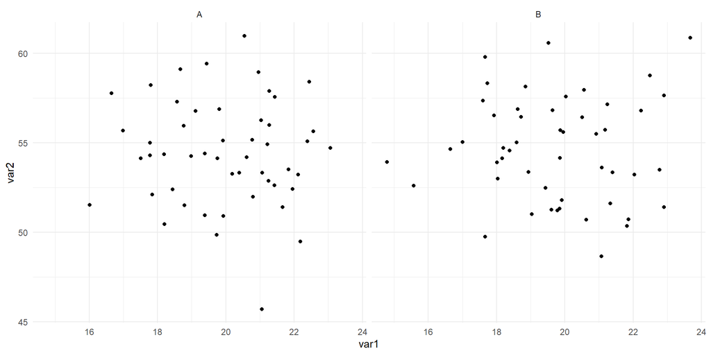

```r
DATA2 |>
  ggplot(mapping = aes(x = var1,
                       y = var2)
         ) +
  geom_point() +
  facet_wrap(facets = vars(group1)) +
  # change the theme
  theme_minimal()
```